# Computational Statistics Lab 6

Group 03 Mohsen Pirmoradiyan, Ahmed Alhasan, Yash Pawar

03 March 2020

## Question 1: Genetic algorithm

In this assignment, you will try to perform one-dimensional maximization with the help of a genetic algorithm.

1. Define the function
   $$f(x) = \frac{x^2}{e^x} - 2 \; exp(-(9 \; sin \; x) / (x^2+x+1))$$

```r
RNGversion(min(as.character(getRversion()), "3.6.2"))

f <- function(x){
  (x^2/exp(x)) - 2 * exp(-(9 * sin(x)/(x^2+x+1)))
}
```

2. Define the function crossover(): for two scalars x and y it returns their “kid” as (x+y)=2.

```r
crossover <- function(x,y){
  (x+y)/2
}
```

3. Define the function mutate() that for a scalar x returns the result of the integer division x2 mod 30. (Operation mod is denoted in R as %%).

```r
mutate <- function(x){
  x^2 %% 30
}
```

4. Write a function that depends on the parameters maxiter and mutprob and:
1. Plots function f in the range from 0 to 30. Do you see any maximum value?
2. Defines an initial population for the genetic algorithm as X = (0,5,10,15,…,30).
3. Computes vector Values that contains the function values for each population point.
4. Performs maxiter iterations where at each iteration
> 1. Two indexes are randomly sampled from the current population, they are further used as parents (use sample()).
> 2. One index with the smallest objective function is selected from the current population, the point is referred to as victim (use order()).
> 3. Parents are used to produce a new kid by crossover. Mutate this kid with probability mutprob (use crossover(), mutate()).
> 4. The victim is replaced by the kid in the population and the vector Values is updated.
> 5. The current maximal value of the objective function is saved.
5. Add the final observations to the current plot in another colour.

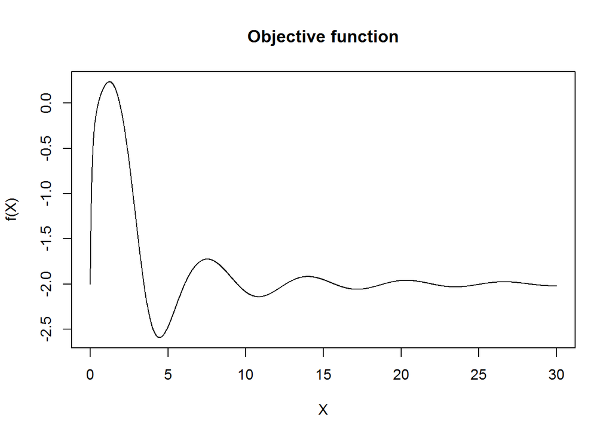

```r
X <- seq(from = 0, to = 30, by = 0.01)
plot(X, f(X), type = "l", main = "Objective function")
```

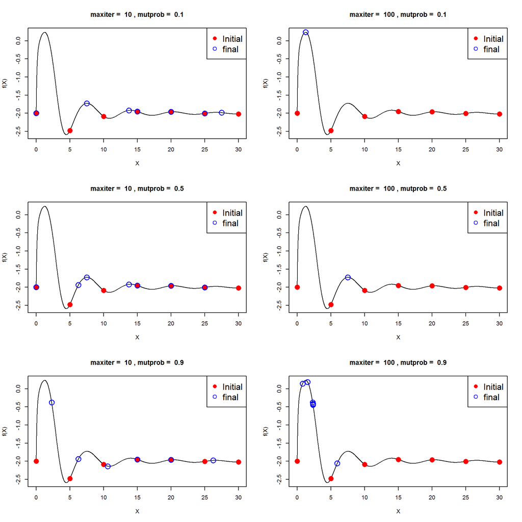

```r
genetic <- function(maxiter, mutprob){
  sinusoid  <- seq(from = 0, to = 30, by = 0.01)
  X         <- seq(from = 0, to = 30, by = 5)
  plot(sinusoid, f(sinusoid), type = "l",
       main = paste("maxiter = ", maxiter, ", mutprob = ", mutprob),
       xlab = "X",
       ylab = "f(X)")
  points(X, f(X), col = "red", pch = 16, cex = 2)

  Values <- f(X)
  for(i in 1:maxiter){
    parents <- sample(X, size = 2)
    victim  <- order(Values)[1]
    kid <- crossover(x = parents[1], y = parents[2])
    kid <- ifelse(mutprob > runif(1), mutate(kid), kid)
    X[victim] <- kid
    Values    <- f(X)
    max_val   <- max(Values)
  }

  points(X, Values, pch = 21, col = "blue", cex = 2, lwd = 1.5)
  legend(x = "topright", legend = c("Initial", "final"), pch = c(16,21),
         col = c("red", "blue"), cex = c(1.5, 1.5))
}

maxiter = c(10, 100)
mutprob = c(0.1, 0.5, 0.9)
par(mfrow = c(3,2))
for(prob in mutprob){
  for(iter in maxiter){
    set.seed(12345)
    genetic(iter, prob)
  }
}
```

## Question 2: EM algorithm

The data file physical.csv describes a behavior of two related physical processes Y = Y (X) and Z = Z(X).

1. Make a time series plot describing dependence of Z and Y versus X. Does it seem that two processes are related to each other? What can you say about the variation of the response values with respect to X?

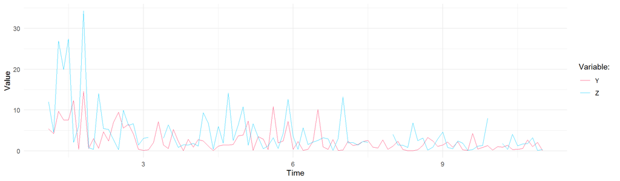

```r
physical <- read.csv("../Data/physical1.csv")
library(ggplot2)
ggplot(physical, aes(x = X)) +
  geom_line(aes(y = Y, col = "Y"), size = .3) +
  geom_line(aes(y = Z, col = "Z"), size = .3) +
  scale_color_manual(values = c("#FF3366", "#00CCFF"), name = "Variable: ") +
  labs(y = "Value", x = "Time") +
  theme_minimal()
```

2. Note that there are some missing values of Z in the data which implies problems in estimating models by maximum likelihood. Use the following model
   $$Y_i \mathcal \; \sim \; exp(X_i/\lambda), \; \; \; \; Z_i \mathcal \; \sim \; exp(X_i/2\lambda)$$
   where $\lambda$ is some unknown parameter. **The goal is to derive an EM algorithm that estimates $\lambda$.**

$$\color{mybrown}{p(Y_i|\lambda) = \frac{X_i}{\lambda} \; \exp(-\frac{X_iY_i}{\lambda}), \;\;\;\; p(Z_i|\lambda) = \frac{X_i}{2\lambda} \; \exp (-\frac{X_iZ_i}{2\lambda})}$$

$$\color{mybrown}{L(\lambda|Y_i,Z_i) = \prod_{i=1}^n p(Y_i|\lambda) . p(Z_i|\lambda) = \prod_{i=1}^n \bigg(\frac{X_i}{\lambda} \; \exp(-\frac{X_iY_i}{\lambda}) \bigg) \bigg( \frac{X_i}{2\lambda} \; \exp (-\frac{X_iZ_i}{2\lambda}) \bigg)}$$

$$\color{mybrown}{= \frac{\prod_{i=1}^n X_i^2}{(2 \lambda^2)^n} \; \exp\bigg(-\frac{1}{\lambda} \sum_{i=1}^{n} X_i Y_i - \frac{1}{2\lambda} \sum_{i=1}^{n} X_i Z_i \bigg)}$$

$$\color{mybrown}{l(\lambda|Y_i,Z_i) = 2\ln\Big(\prod_{i=1}^n X_i\Big)-\Big(n\ln(2)+2n\ln(\lambda) \Big) -\frac{1}{\lambda}\sum_{i=1}^{n} X_i Y_i - \frac{1}{2\lambda} \sum_{i=1}^{n} X_i Z_i}$$

$$\color{mybrown}{l(\lambda|Y_i,Z_i) = 2\ln\Big(\prod_{i=1}^n X_i\Big)-\Big(n\ln(2)+2n\ln(\lambda) \Big) - \frac{1}{\lambda} \sum_{i=1}^{n} X_i Y_i - \frac{1}{2\lambda} \sum_{i\in Observed} X_i Z_i - \frac{1}{2\lambda} \sum_{j\in Missing} X_j Z_j}$$

$$\color{mybrown}{E[l(\lambda|Y_i,Z_i)] = E\Bigg[ 2\ln\Big(\prod_{i=1}^n X_i\Big)-\Big(n\ln(2)+2n\ln(\lambda) \Big) - \frac{1}{\lambda} \sum_{i=1}^{n} X_i Y_i -\frac{1}{2\lambda} \sum_{i\in Observed} X_i Z_i - \frac{1}{2\lambda} \sum_{j\in Missing} X_j Z_j \Bigg]}$$

$$\color{mybrown}{E[Z_j] = \frac{2\lambda_t}{X_j}, \;\;\;where \; \lambda_t \; is \; the \; lambda \; from \; last \; iteration}$$
$$\color{mybrown}{E \bigg[\frac{1}{2\lambda} \sum_{j\in Missing} X_j Z_j \bigg] = M \frac{\lambda_t}{\lambda}, \;\;\; where \; M \; is \; the \; number \; of \; missing \; values}$$

$$\color{mybrown}{E[l(\lambda|Y_i,Z_i)] = 2\ln\Big(\prod_{i=1}^n X_i\Big)-\Big(n\ln(2)+2n\ln(\lambda) \Big) - \frac{1}{\lambda} \sum_{i=1}^{n} X_i Y_i - \frac{1}{2\lambda} \sum_{i\in K} X_i Z_i - M \frac{\lambda_t}{\lambda}}$$

$$\color{mybrown}{\frac{\partial E[l(\lambda|Y_i,Z_i)]}{\partial \lambda} = -\frac{2n}{\lambda} + \frac{1}{\lambda^2} \sum_{i=1}^{n} X_i Y_i + \frac{1}{2\lambda^2}\sum_{i\in Observed} X_i Z_i + M\frac{\lambda_t}{ \lambda^2} = 0}$$

$$\color{mybrown}{\lambda_{t+1} = \frac{1}{2n} \bigg(\sum_{i=1}^{n} X_i Y_i+\frac{1}{2}\sum_{i\in Observed} X_i Z_i + M\lambda_t \bigg)}$$

3. Implement this algorithm in R, use $\lambda_0$ = 100 and convergence criterion “stop if the change in $\lambda$ is less than 0.001”. What is the optimal $\lambda$ and how many iterations were required to compute it?

```r
#Estimate lambda according to the resoults in 2.
lambdaest<-function(n,lambda_k,X,Z,Y,L,not_missing){
  return(1/(2*n)*(sum(X*Y)+1/2*sum(X[not_missing]*Z[not_missing])+L*lambda_k))
}
```

```r
EM_exp <- function(threshold,data,initial,kstep){ # EM algorithm
  lambda0 <- initial
  logli_old = 0
  stop_indicator = 0
  n<-nrow(data)
  n_NA<-length(is.na(data$Z))
  full_index <- which(!is.na(data$Z))
  cat("iteraction: 0 Lambda is:",lambda0,"\n")
  k<-1
  while (stop_indicator != 1){
    # E-step
      lambda1 <- lambdaest(n=n,lambda_k=lambda0,X=data$X, Y=data$Y,Z=data$Z,L=n_NA, not_missing = full_index)
    logli_new<- 2*log(prod(data$X))-(n*log(2)+2*n*log(lambda0)) -
              (1/lambda0)*sum(data$X*data$Y)- (1/(2*lambda0))*
              sum(data$X[full_index]*data$Z[full_index])-n_NA*lambda1/lambda0

    # M-step
    lambda0 <- lambda1
    cat("iteraction:",k,"Lambda is:",lambda0,"\n")

    # likelihood test
    if (abs(logli_old-logli_new)< threshold || k> kstep){
      break
    }
    k<-k+1
    logli_old <- logli_new
  }
  return(list(lambda=lambda0, loglik = logli_new, k=k))
}
```

```r
EM_run <- EM_exp(0.0001,physical,100,100)
```

```
## iteraction: 0 Lambda is: 100
## iteraction: 1 Lambda is: 60.26782
## iteraction: 2 Lambda is: 40.40173
## iteraction: 3 Lambda is: 30.46869
## iteraction: 4 Lambda is: 25.50216
## iteraction: 5 Lambda is: 23.0189
## iteraction: 6 Lambda is: 21.77727
## iteraction: 7 Lambda is: 21.15646
## iteraction: 8 Lambda is: 20.84605
## iteraction: 9 Lambda is: 20.69084
## iteraction: 10 Lambda is: 20.61324
## iteraction: 11 Lambda is: 20.57444
## iteraction: 12 Lambda is: 20.55504
## iteraction: 13 Lambda is: 20.54534
## iteraction: 14 Lambda is: 20.54049
## iteraction: 15 Lambda is: 20.53807
## iteraction: 16 Lambda is: 20.53685
## iteraction: 17 Lambda is: 20.53625
## iteraction: 18 Lambda is: 20.53594
## iteraction: 19 Lambda is: 20.53579
## iteraction: 20 Lambda is: 20.53572
## iteraction: 21 Lambda is: 20.53568
## iteraction: 22 Lambda is: 20.53566
```

```r
lambda_opti<-EM_run$lambda
```

Our initial $\lambda= 100$ and after 22 iteractions we estimated too $\lambda =$ 20.5356599 with a log likelihood -543.8274934.

## 4

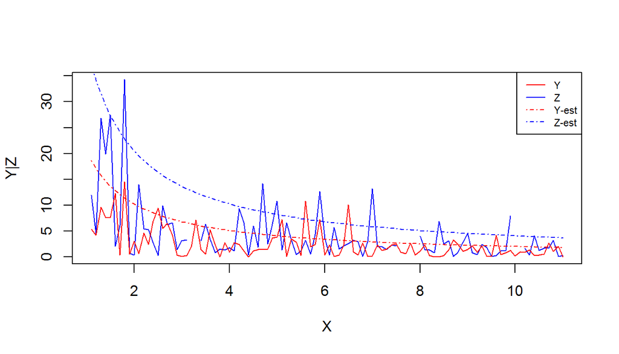

From the Figure we can find that the estimated expectations generally follows the trend of the data. However, since there are some outliers existing in the data, the accuracy of the estimations is compromised.

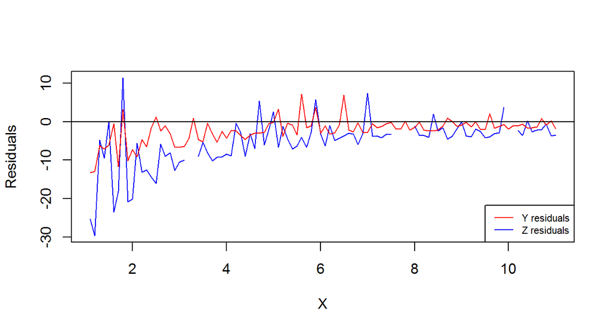

Visual inspection shows that the estimation of $Y$ is better than the estimation of $Z$, because its residuals are more similar to white noise.

## Appendix

```r
knitr::opts_chunk$set(echo = TRUE)
RNGversion(min(as.character(getRversion()), "3.6.2"))

f <- function(x){
  (x^2/exp(x)) - 2 * exp(-(9 * sin(x)/(x^2+x+1)))
}
crossover <- function(x,y){
  (x+y)/2
}
mutate <- function(x){
  x^2 %% 30
}
X <- seq(from = 0, to = 30, by = 0.01)
plot(X, f(X), type = "l", main = "Objective function")
genetic <- function(maxiter, mutprob){
  sinusoid  <- seq(from = 0, to = 30, by = 0.01)
  X         <- seq(from = 0, to = 30, by = 5)
  plot(sinusoid, f(sinusoid), type = "l",
       main = paste("maxiter = ", maxiter, ", mutprob = ", mutprob),
       xlab = "X",
       ylab = "f(X)")
  points(X, f(X), col = "red", pch = 16, cex = 2)

  Values <- f(X)
  for(i in 1:maxiter){
    parents <- sample(X, size = 2)
    victim  <- order(Values)[1]
    kid <- crossover(x = parents[1], y = parents[2])
    kid <- ifelse(mutprob > runif(1), mutate(kid), kid)
    X[victim] <- kid
    Values    <- f(X)
    max_val   <- max(Values)
  }

  points(X, Values, pch = 21, col = "blue", cex = 2, lwd = 1.5)
  legend(x = "topright", legend = c("Initial", "final"), pch = c(16,21),
         col = c("red", "blue"), cex = c(1.5, 1.5))
}

maxiter = c(10, 100)
mutprob = c(0.1, 0.5, 0.9)
par(mfrow = c(3,2))
for(prob in mutprob){
  for(iter in maxiter){
    set.seed(12345)
    genetic(iter, prob)
  }
}
physical <- read.csv("../Data/physical1.csv")
library(ggplot2)
ggplot(physical, aes(x = X)) +
  geom_line(aes(y = Y, col = "Y"), size = .3) +
  geom_line(aes(y = Z, col = "Z"), size = .3) +
  scale_color_manual(values = c("#FF3366", "#00CCFF"), name = "Variable: ") +
  labs(y = "Value", x = "Time") +
  theme_minimal()
#Estimate lambda according to the resoults in 2.
lambdaest<-function(n,lambda_k,X,Z,Y,L,not_missing){
  return(1/(2*n)*(sum(X*Y)+1/2*sum(X[not_missing]*Z[not_missing])+L*lambda_k))
}
EM_exp <- function(threshold,data,initial,kstep){ # EM algorithm
  lambda0 <- initial
  logli_old = 0
  stop_indicator = 0
  n<-nrow(data)
  n_NA<-length(is.na(data$Z))
  full_index <- which(!is.na(data$Z))
  cat("iteraction: 0 Lambda is:",lambda0,"\n")
  k<-1
  while (stop_indicator != 1){
    # E-step
      lambda1 <- lambdaest(n=n,lambda_k=lambda0,X=data$X, Y=data$Y,Z=data$Z,L=n_NA, not_missing = full_index)
    logli_new<- 2*log(prod(data$X))-(n*log(2)+2*n*log(lambda0)) -
              (1/lambda0)*sum(data$X*data$Y)- (1/(2*lambda0))*
              sum(data$X[full_index]*data$Z[full_index])-n_NA*lambda1/lambda0

    # M-step
    lambda0 <- lambda1
    cat("iteraction:",k,"Lambda is:",lambda0,"\n")

    # likelihood test
    if (abs(logli_old-logli_new)< threshold || k> kstep){
      break
    }
    k<-k+1
    logli_old <- logli_new
  }
  return(list(lambda=lambda0, loglik = logli_new, k=k))
}
EM_run <- EM_exp(0.0001,physical,100,100)
lambda_opti<-EM_run$lambda
plot(physical$Z ~ physical$X, type="l", col="blue", xlab="X", ylab="Y|Z")
lines(physical$Y ~ physical$X, col="red")
lines(physical$X,lambda_opti/physical$X,col="red",lty=4)
lines(physical$X,(2*lambda_opti)/physical$X,col="blue",lty=4)
legend("topright", legend=c("Y","Z","Y-est","Z-est"), col=c("red","blue","red","blue"), lty=c(1,1,4,4), cex=.7)
plot(physical$X,physical$Z-(2*lambda_opti)/physical$X,col='blue',type='l',xlab = 'X',ylab = 'Residuals')
lines(physical$X,physical$Y-lambda_opti/physical$X,col="red")
abline(h=0)
legend("bottomright", legend=c("Y residuals","Z residuals"), col=c("red","blue"), lty=c(1,1), cex=.7)
```

## References

Deepti Gupta, Shabina Ghafir. 2012. “An Overview of Methods Maintaining Diversity in Genetic Algorithms.” *International Journal of Emerging Technology and Advanced Engineering* 2.